# Practice Final

## Question 1

Perform an appropriate hypothesis test in R to decide if the medians displayed in the graph are significantly different or not.

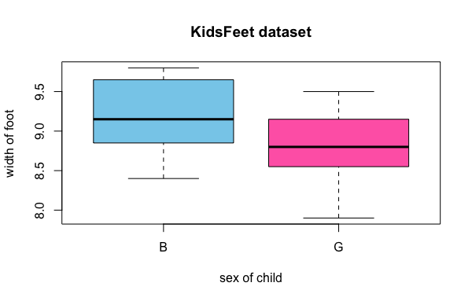

```r
t.test(width ~ sex, data = KidsFeet, mu = 0, alternative = "two.sided", conf.level = 0.95)
```

```
##
##  Welch Two Sample t-test
##
## data:  width by sex
## t = 2.6741, df = 36.281, p-value = 0.01117
## alternative hypothesis: true difference in means is not equal to 0
## 95 percent confidence interval:
##  0.09811171 0.71346724
## sample estimates:
## mean in group B mean in group G
##        9.190000        8.784211
```

## Question 2

What is the correct conclusion to make in a logistic regression when the goodness of fit test (either one) gives a p-value of 0.352?

— Continue to believe the logistic regression was appropriate to perform on the given data.

## Question 3

A permutation test for a Kruskal-Wallis Test Statistic is performed with the following result:

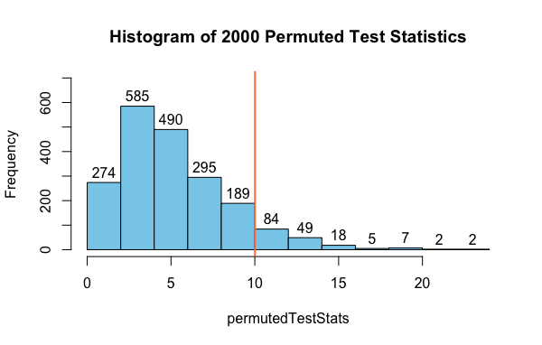

Note that the numbers above the bars state the frequency of observations contained in that bar.

What is the p-value of this permutation test?

## Question 4

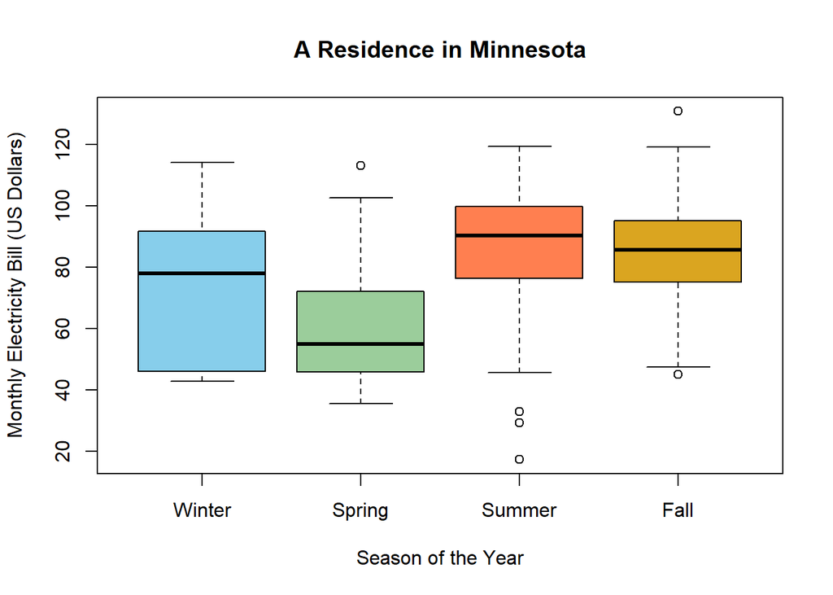

```r
Util <- Utilities

Util$Season <- cut(Util$month%%12, c(0,2,5,8,11), c("Winter","Spring","Summer","Fall"))

boxplot(elecbill ~ Season, data=Util, main="A Residence in Minnesota", ylab="Monthly Electricity Bill (US Dollars)", xlab="Season of the Year", col=c("skyblue","darkseagreen3","coral","goldenrod"))
```

```r
pander(summary(aov(elecbill ~ Season, data=Util, mu = 0, alternative = "two.sided", conf.level = 0.95)))
```

Analysis of Variance Model

|  | Df | Sum Sq | Mean Sq | F value | Pr(>F) |
| --- | --- | --- | --- | --- | --- |
| **Season** | 3 | 11172 | 3724 | 7.234 | 0.0001879 |
| **Residuals** | 103 | 53023 | 514.8 | NA | NA |

— F-statistic: 7.234 on 3 and 103 DF, p-value: 0.0001879

## Question 5

What does each row of the Utilities dataset represent?

```r
?Utilities
```

## Question 6

Run the following codes in R.

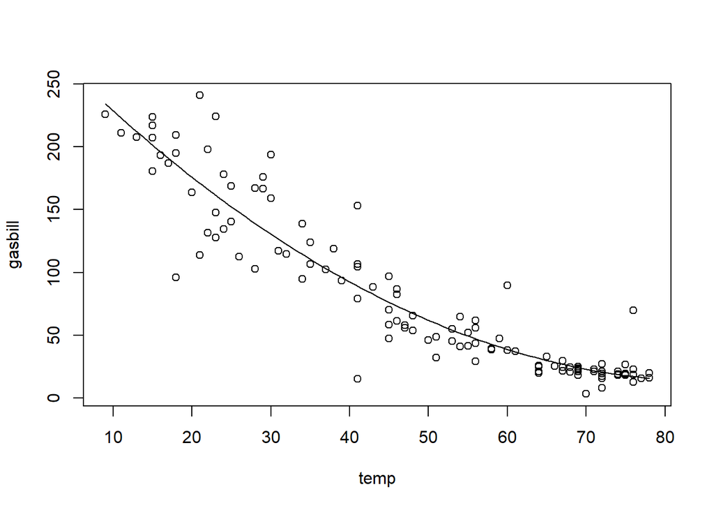

```r
util.lm <- lm(gasbill ~ temp + I(temp^2), data=Utilities)
plot(gasbill ~ temp, data=Utilities)
b <- util.lm$coefficients
curve(b[1] + b[2]*x + b[3]*x^2, add=TRUE)
```

```r
pander(summary(util.lm))
```

|  | Estimate | Std. Error | t value | Pr(>\|t\|) |
| --- | --- | --- | --- | --- |
| **(Intercept)** | 288.8 | 12.04 | 23.99 | 2.254e-46 |
| **temp** | -6.387 | 0.5885 | -10.85 | 2.822e-19 |
| **I(temp^2)** | 0.03703 | 0.006276 | 5.9 | 3.804e-08 |

Fitting linear model: gasbill ~ temp + I(temp^2)

| Observations | Residual Std. Error | $R^2$ | Adjusted $R^2$ |
| --- | --- | --- | --- |
| 117 | 23.25 | 0.88 | 0.8779 |

Which of the following correctly states the mathematical model for the above regression?

## Question 7

— Beautiful Summers but Freezing Winters

## Question 8

Run the following codes in R.

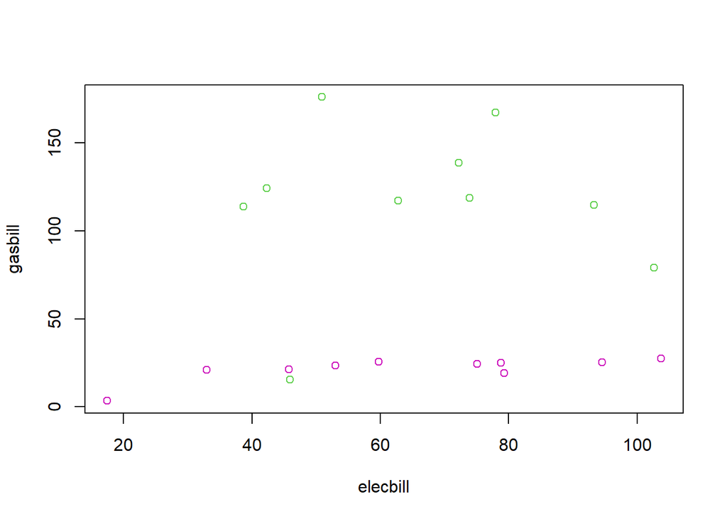

```r
U2 <- subset(Utilities, month %in% c(3,6))
plot(gasbill ~ elecbill, data=U2, col=month)
```

Perform an analysis that allows you to place two separate lines on this scatterplot.

Report the p-value of the test of whether these lines have significantly different slopes or not.

```r
pander(summary(aov(gasbill ~ elecbill+month+elecbill:month, data=U2)))
```

Analysis of Variance Model

|  | Df | Sum Sq | Mean Sq | F value | Pr(>F) |
| --- | --- | --- | --- | --- | --- |
| **elecbill** | 1 | 589.1 | 589.1 | 0.5098 | 0.4855 |
| **month** | 1 | 44668 | 44668 | 38.65 | 1.233e-05 |
| **elecbill:month** | 1 | 23.53 | 23.53 | 0.02036 | 0.8883 |
| **Residuals** | 16 | 18491 | 1156 | NA | NA |

— No significant difference in slopes, p-value = 0.8883.

## Question 9

A group of Math 221 students performed a reseearch project for their class studying the parking abilities of men and women at BYU-Idaho. Essentially, they watched people park and recorded the final parking as “well done”, “crooked”, or “failed”. They also recorded the gender of the person parking the vehicle.

What type of analyses would best help them determine if men or women are better at parking?

— Chi Squared Test

## Question 10

Suppose the homeowner of the home where the Utilities dataset was collected from approached you with the question: “How much should I plan on my electric bill costing me this July?”

Use the Utilities dataset in R to perform some useful calculations in order to answer their question.

```r
pander(favstats(elecbill~month, data = Utilities)[,-10])
```

| month | min | Q1 | median | Q3 | max | mean | sd | n |
| --- | --- | --- | --- | --- | --- | --- | --- | --- |
| 1 | 43.3 | 47.17 | 80.5 | 93.85 | 110.4 | 75.43 | 27.18 | 8 |
| 2 | 42.83 | 45.56 | 65.94 | 91.59 | 114 | 70.15 | 27.42 | 10 |
| 3 | 38.69 | 47.19 | 67.5 | 76.95 | 102.7 | 66.07 | 21.81 | 10 |
| 4 | 35.7 | 40.65 | 53.7 | 61.55 | 95.22 | 55.41 | 18.81 | 10 |
| 5 | 38.55 | 50.16 | 54.66 | 64.92 | 113.2 | 61 | 20.53 | 10 |
| 6 | 17.43 | 47.59 | 67.41 | 79.19 | 103.7 | 64.03 | 27.26 | 10 |
| 7 | 29.32 | 91.56 | 94.69 | 99.07 | 114.9 | 90.69 | 23.88 | 10 |
| 8 | 76.45 | 85.15 | 93.1 | 103.5 | 119.3 | 94.59 | 13.51 | 10 |
| 9 | 82.2 | 86.17 | 95.63 | 109.3 | 130.8 | 99.16 | 16.52 | 10 |
| 10 | 66.31 | 75.2 | 85.81 | 94.88 | 102.5 | 84.91 | 13.32 | 9 |
| 11 | 45.01 | 63.3 | 74.38 | 83.79 | 92.58 | 71.96 | 16.86 | 10 |
| 12 | 46.59 | 68.77 | 80.28 | 99.22 | 152.2 | 87.21 | 31.74 | 10 |

```r
U3 <- Utilities %>% filter(month == 7)

pander(favstats(elecbill~day, data = U3)[,-10])
```

| day | min | Q1 | median | Q3 | max | mean | sd | n |
| --- | --- | --- | --- | --- | --- | --- | --- | --- |
| 26 | 79.57 | 86.97 | 94.36 | 104.6 | 114.9 | 96.28 | 17.74 | 3 |
| 27 | 29.32 | 75.62 | 93.91 | 100.8 | 113 | 82.53 | 36.67 | 4 |
| 28 | 93.04 | 94.03 | 95.01 | 97.43 | 99.84 | 95.96 | 3.499 | 3 |

Then, select the best answer from the list below.

— Based on your past data, it looks like you have spent as little as $29.32 and as much as $114.90 on electricity in July. However, 3 out of every 4 bills in July was between $91.55 abd $114.90. So planning on at least $90 is probably a safe bet.

## Question 11

A common mistake of introductory statistics students is to make a graph like the following.

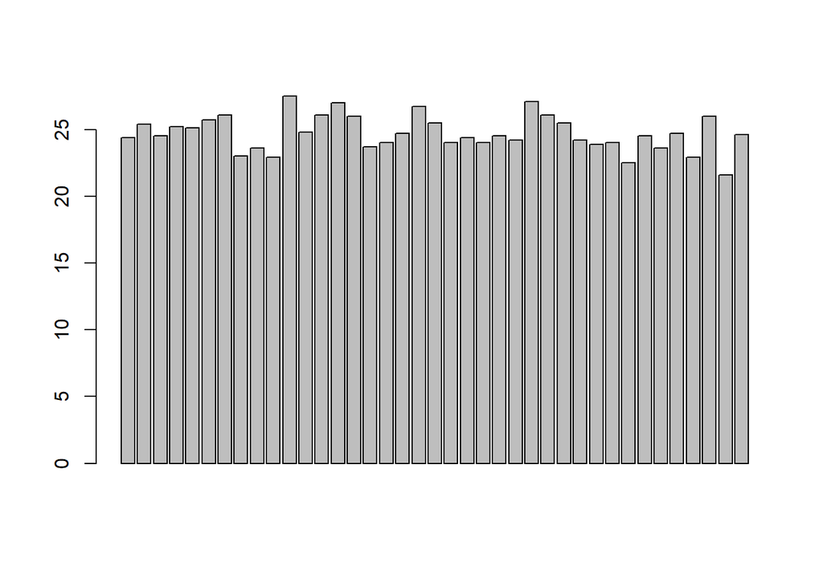

```r
barplot(KidsFeet$length)
```

Select the graph from the options below that would be more appropriate for visualizing the distribution of this data.

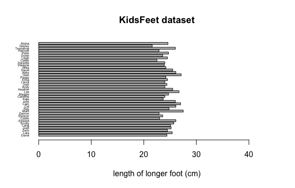

## Question 12

Which type of analysis would be best for analyzing the data shown in this boxplot?

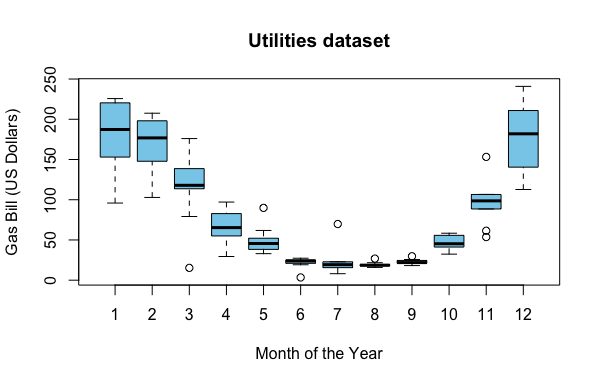

— A Kruskal-Wallis Test

## Question 13

Use the Utilities dataset in R to perform a linear regression that would place a simple linear regression line on this graph.

```r
pandary(mylm <- lm(elecbill ~ kwh, data = Utilities))
```

|  | Estimate | Std. Error | t value | Pr(>\|t\|) |
| --- | --- | --- | --- | --- |
| **(Intercept)** | -5.001 | 4.522 | -1.106 | 0.2711 |
| **kwh** | 0.1088 | 0.005816 | 18.7 | 1.155e-36 |

Fitting linear model: elecbill ~ kwh

| Observations | Residual Std. Error | $R^2$ | Adjusted $R^2$ |
| --- | --- | --- | --- |
| 117 | 12.66 | 0.7525 | 0.7503 |

```r
predict(mylm, data.frame(kwh = 1))
```

```
##        1
## -4.89196
```

```r
predict(mylm, data.frame(kwh = 2))
```

```
##         1
## -4.783206
```

```r
predict(mylm, data.frame(kwh = 3))
```

```
##         1
## -4.674452
```

Which of the following correctly interprets the slope of the line from this regression? (You may need to scroll down to see the answer options.)

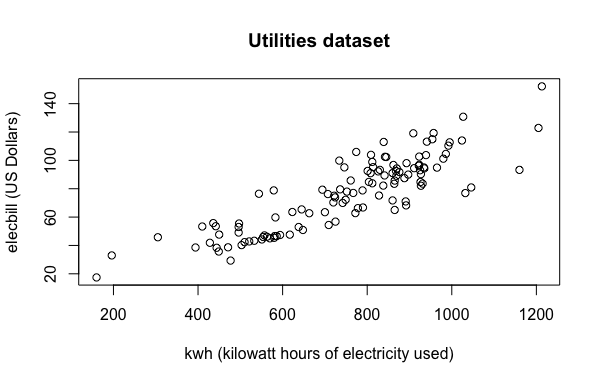

— This homeowner is being charged an average of 10.9 cents per kilowatt hour of electricity used.

## Question 14

Consider the output of a chi squared test performed in R that is shown below. What is the p-value of the test?

```r
chisq.test(table(gender, groupId))
```

Pearson’s Chi-squared test

data: table(gender, groupId)) X-squared = 4.9575, df = 2, p-value = ________

— 0.0838

## Question 15

Use the KidsFeet dataset in R to calculate the predicted probability that the birthyear of a child is ’88 when the length of the foot (measured in October of 1997) is 26 cm long. (Scroll down to select your answer.)

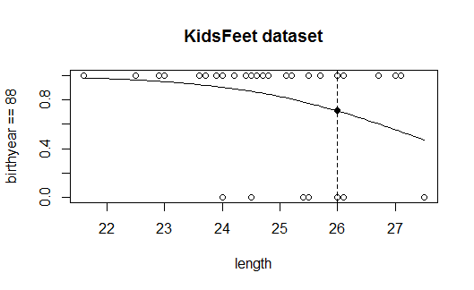

— 0.711

## Question 16

Report the p-value of your test.

```r
pandary(lm(width~birthmonth, data = KidsFeet))
```

|  | Estimate | Std. Error | t value | Pr(>\|t\|) |
| --- | --- | --- | --- | --- |
| **(Intercept)** | 8.993 | 0.1731 | 51.96 | 3.472e-36 |
| **birthmonth** | -0.0001612 | 0.02492 | -0.006468 | 0.9949 |

Fitting linear model: width ~ birthmonth

| Observations | Residual Std. Error | $R^2$ | Adjusted $R^2$ |
| --- | --- | --- | --- |
| 39 | 0.5164 | 1.131e-06 | -0.02703 |

— P-value = 0.995

## Question 17

— Every 1 unit increase in X results in a 1.47% drop in the odds that Yi=1.

## Question 18

Which of the following graphics correctly depicts the results of an analysis that uses the disp and drat columns of the mtcars dataset?

```r
pandary(lm(disp~drat, data = mtcars))
```

|  | Estimate | Std. Error | t value | Pr(>\|t\|) |
| --- | --- | --- | --- | --- |
| **(Intercept)** | 822.8 | 108.3 | 7.598 | 1.793e-08 |
| **drat** | -164.6 | 29.79 | -5.526 | 5.282e-06 |

Fitting linear model: disp ~ drat

| Observations | Residual Std. Error | $R^2$ | Adjusted $R^2$ |
| --- | --- | --- | --- |
| 32 | 88.69 | 0.5044 | 0.4879 |

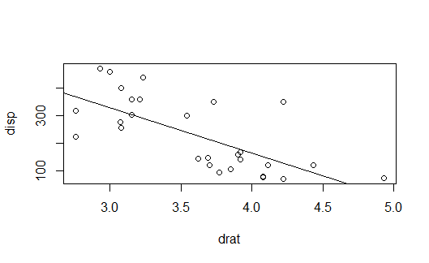

## Question 19

A student tried to perform the following t Test in R, but got an error message. Go ahead and run the code yourself to see the error message.

```r
t.test(mpg ~ cyl, data=mtcars)
```

Which of the following would provide the student with a solution to this error message?

— Try using kruskal.test(…) instead of t.test(…).

```r
kruskal.test(mpg ~ cyl, data=mtcars)
```

```
##
##  Kruskal-Wallis rank sum test
##
## data:  mpg by cyl
## Kruskal-Wallis chi-squared = 25.746, df = 2, p-value = 2.566e-06
```

## Question 20

Run the following codes in R.

```r
View(mtcars)

?mtcars
```

If a researcher were to use only the hp and vs columns, which type of analysis would NOT make sense to try and perform with this data as it is currently shown?

```r
mtCars <- mtcars %>% select(hp, vs)

pander(mtCars)
```

|  | hp | vs |
| --- | --- | --- |
| **Mazda RX4** | 110 | 0 |
| **Mazda RX4 Wag** | 110 | 0 |
| **Datsun 710** | 93 | 1 |
| **Hornet 4 Drive** | 110 | 1 |
| **Hornet Sportabout** | 175 | 0 |
| **Valiant** | 105 | 1 |
| **Duster 360** | 245 | 0 |
| **Merc 240D** | 62 | 1 |
| **Merc 230** | 95 | 1 |
| **Merc 280** | 123 | 1 |
| **Merc 280C** | 123 | 1 |
| **Merc 450SE** | 180 | 0 |
| **Merc 450SL** | 180 | 0 |
| **Merc 450SLC** | 180 | 0 |
| **Cadillac Fleetwood** | 205 | 0 |
| **Lincoln Continental** | 215 | 0 |
| **Chrysler Imperial** | 230 | 0 |
| **Fiat 128** | 66 | 1 |
| **Honda Civic** | 52 | 1 |
| **Toyota Corolla** | 65 | 1 |
| **Toyota Corona** | 97 | 1 |
| **Dodge Challenger** | 150 | 0 |
| **AMC Javelin** | 150 | 0 |
| **Camaro Z28** | 245 | 0 |
| **Pontiac Firebird** | 175 | 0 |
| **Fiat X1-9** | 66 | 1 |
| **Porsche 914-2** | 91 | 0 |
| **Lotus Europa** | 113 | 1 |
| **Ford Pantera L** | 264 | 0 |
| **Ferrari Dino** | 175 | 0 |
| **Maserati Bora** | 335 | 0 |
| **Volvo 142E** | 109 | 1 |

— A chi-squared Test.

## Question 21

Make a boxplot in R which depicts the length of feet for right-handed and left-handed kids as recorded in the KidsFeet dataset.

Select the graphic you obtain from the options below.

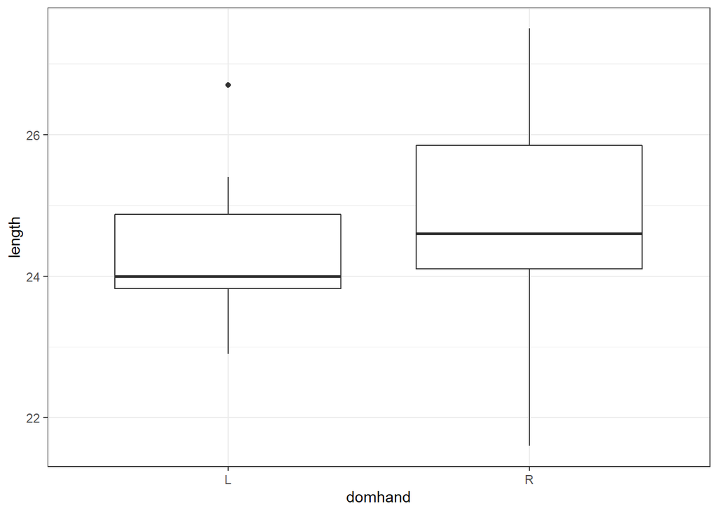

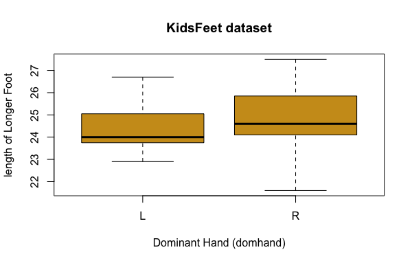

```r
ggplot(data = KidsFeet, aes(x = domhand, y = length)) +
  geom_boxplot() +
  theme_bw()
```

## Question 22

A certain hospital collected data from mothers who recently gave birth. They asked the mother if she smoked at all during the pregnancy and recorded her answer as either “yes” or “no”. They also recorded the birth weight of the newborn child in grams.

If a logistic regression were used with this data, which of the following would properly word the question for the analysis?

— Does smoking during a pregnancy effect the birth weight of the child?

## Question 23

Use the KidsFeet dataset in R. Which of the following correctly displays how many boys (B) and girls (G) from the dataset were born in each month of the year? (Jan = 1, …, Dec = 12)

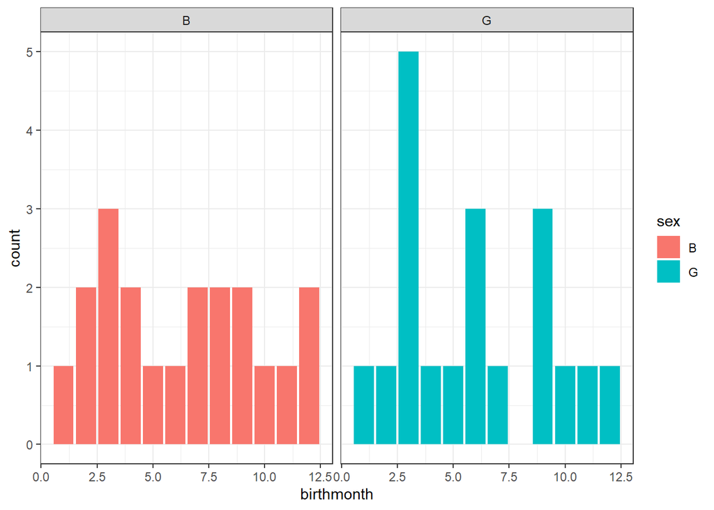

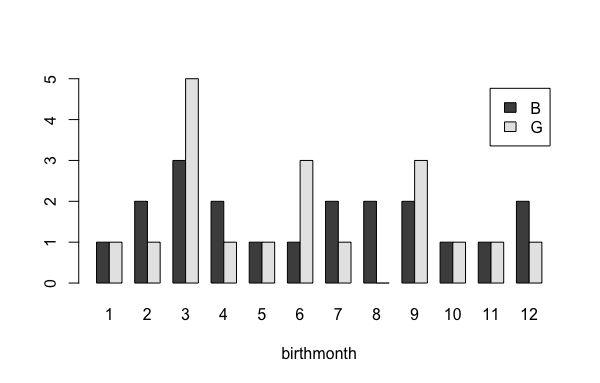

```r
ggplot(data = KidsFeet, aes(x=birthmonth, fill = sex)) +
  geom_bar()+
  facet_grid(~sex) +
  theme_bw()
```

## Question 24

What two things are needed to compute a p-value?

— A test statistic and a distribution of the test statistic.

## Question 25

Use the KidsFeet dataset in R to calculate the average foot length of the boys in the dataset who were born in January.

```r
kidsfeet <- KidsFeet %>%
  filter(birthmonth == 1) %>%
  filter(sex == "B")

mean(kidsfeet$length)
```

```
## [1] 25.2
```

— 25.2